# Gen3sis

Author

Friederike Wölke, wolke@fzp.czu.cz, Room D330

# Simulating macroevolutionary and biogeographic dynamics across space and time

Gen3sis (Hagen et al.) provides a framework to model how species evolve, interact with their environment, disperse, and diversify across landscapes. gen3sis is especially useful for studying species diversification, speciation, extinction, and migration under varying environmental and geological conditions.

**⭐Key Features**

- *Species Evolution and Diversification*: Simulates speciation events based on user-defined rules.
- *Dispersal*: Models how species disperse across landscapes, incorporating environmental and geographical barriers.
- *Environmental Changes*: Accounts for changes in the environment over time, allowing for the study of how species respond to climate changes and other disturbances.
- *Custom Scenarios*: Users can set up custom biogeographic, environmental, and evolutionary scenarios to test hypotheses.

```r
rm(list = ls())
library(here)
library(gen3sis)
library(terra)
library(tictoc)
```

```r
# check the package version, we are on 1.5.11
packageVersion("gen3sis")
```

```
[1] '1.5.11'
```

## Simplified workflow

**To get started, the engine requires the following information:**

1. The **configuration** of the eco-evolutionary processes (i.e., parameters for dispersal, speciation, mutation and ecology)
2. The time-series of the **landscape** in which these processes happen (including plate tectonics, mountain building, sea level changes, etc.)  
   *Example resources*:
   - CHELSA or Bio-oracle future climate projections;
   - CHELSA climate change since the last glacial maximum to the present
   - Tristan Salles et al’s landscape reconstructions: https://www.science.org/doi/10.1126/science.add2541
   - Make your own landscape (IT’S FUN)!! (tutorial: https://alexskeels.github.io/CBAGen3sis/Day2_Prac5_landscapes.html)

# Example data

We will use the example data that comes with the `gen3sis package`. You don’t have to adjust the code below. If the installation of *gen3sis* worked, the code below should work as well.

```r
# here()

data_path <- file.path(here("SouthAmerica"))
# list.files(data_path, recursive = T)

path_config <- file.path(data_path, "config/config_southamerica.R")
path_landscape <- file.path(data_path, "landscape")

# load(".RData")
```

## Configurations

The **config** is the code for the ecological and evolutionary rules and other parameters of Gen3sis, such as the random seed, instructions on saving output.

**⭐config**

A config file is a a stand-alone R script which is modified by you. You can modify a config in two ways. The first way and most practical, is to open up a config.R file from your file explorer. The second way includes loading the file into R as config for gen3sis and adjust it in R. To keep our simulations reproducible and all changes we make to the config, we will modify the file from within R.

```r
# gen3sis-function to initialize the config file (to tell the model what to use)
config_raw <- create_input_config(config_file = path_config)
```

We can edit config files like this:

```r
file.edit(here(data_path, "config" , "config_sim1.R"))
```

## Landscape

**⭐ landscape & distances**

The landscape is made up of 2 classes of files:

1) The landscape object with latitude, longitude and environmental variables;

2) The distance matrices that set the dispersal options for species in the landscape.

For this, the user has to define a cost-function for dispersal over ‘terrestrial’ patches or ‘water’ patches. For terrestrial species, the cost function should be higher on water patches than on terrestrial patches. For water-species, the cost function for terrestrial patches should be infinite (water-species do not disperse over land).

The distances are calculated during the creation of the world with the function: `create_input_landscape(…,calculate_full_distance_matrices = TRUE)`

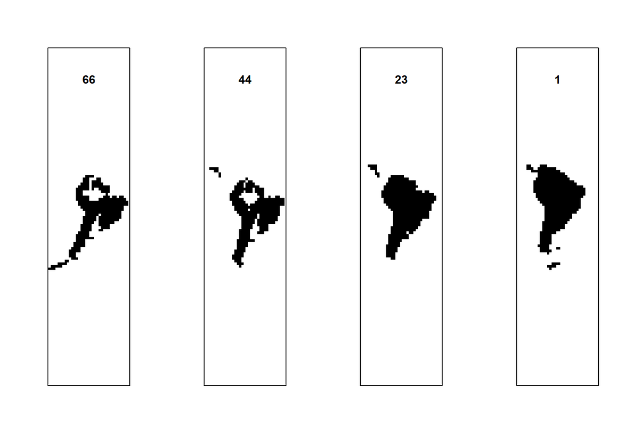

```r
## Environmental landscape
landscape <- readRDS(file.path(path_landscape, "landscapes.rds"))

# plot the landscape
gen3sis::plot_landscape_overview(landscape)
```

```r
# Inspect the object
class(landscape)
```

```
[1] "list"
```

```r
# which environmental variables do we have?
names(landscape)
```

```
[1] "temp" "arid" "area"
```

```r
# Which time periods do we have?
names(landscape$temp)
```

```
 [1] "x"  "y"  "1"  "2"  "3"  "4"  "5"  "6"  "7"  "8"  "9"  "10" "11" "12" "13"
[16] "14" "15" "16" "17" "18" "19" "20" "21" "22" "23" "24" "25" "26" "27" "28"
[31] "29" "30" "31" "32" "33" "34" "35" "36" "37" "38" "39" "40" "41" "42" "43"
[46] "44" "45" "46" "47" "48" "49" "50" "51" "52" "53" "54" "55" "56" "57" "58"
[61] "59" "60" "61" "62" "63" "64" "65" "66"
```

```r
# How does it look?
landscape$temp[1:3, 1:9]
```

```
    x  y  1  2  3  4  5  6  7
1 -94 12 NA NA NA NA NA NA NA
2 -92 12 NA NA NA NA NA NA NA
3 -90 12 NA NA NA NA NA NA NA
```

#### 🖼️Landscape overview plots

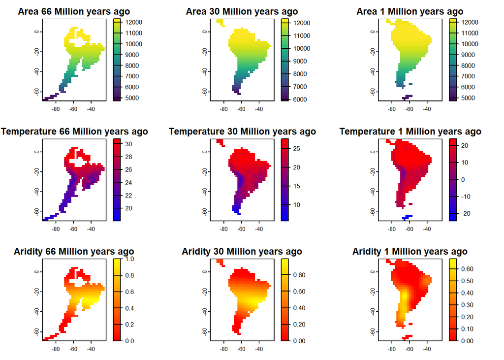

```r
# Define color palettes
temp_colors <- colorRampPalette(c("blue", "red")) # Blue to red for temperature
arid_colors <- colorRampPalette(c("red", "yellow")) # Red to yellow for aridity

par(mfrow = c(3, 3))


# Plotting the areas
plot(terra::rast(landscape$area[, c("x", "y", "66")]),
     main = "Area 66 Million years ago")

plot(terra::rast(landscape$area[, c("x", "y", "30")]),
     main = "Area 30 Million years ago")

plot(terra::rast(landscape$area[, c("x", "y", "1")]),
     main = "Area 1 Million years ago")



# Plotting temperature with custom colors
plot(terra::rast(landscape$temp[, c("x", "y", "66")]),
     main = "Temperature 66 Million years ago",
     col = temp_colors(100))

plot(terra::rast(landscape$temp[, c("x", "y", "30")]),
     main = "Temperature 30 Million years ago",
     col = temp_colors(100))

plot(terra::rast(landscape$temp[, c("x", "y", "1")]),
     main = "Temperature 1 Million years ago",
     col = temp_colors(100))



# Plotting aridity with custom colors
plot(terra::rast(landscape$arid[, c("x", "y", "66")]),
     main = "Aridity 66 Million years ago",
     col = arid_colors(100))

plot(terra::rast(landscape$arid[, c("x", "y", "30")]),
     main = "Aridity 30 Million years ago",
     col = arid_colors(100))

plot(terra::rast(landscape$arid[, c("x", "y", "1")]),
     main = "Aridity 1 Million years ago",
     col = arid_colors(100))
```

#### 🖼️Climate Graphs

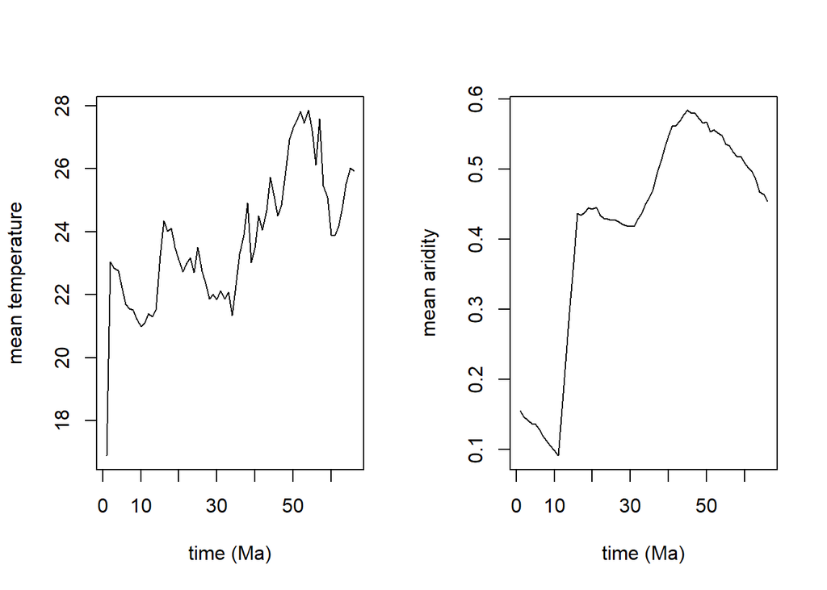

```r
par(mfrow = c(1, 2))

# plot the change in mean tempereature through time
mean_temperatures <- colMeans(landscape$temp[, 3:ncol(landscape$temp)], na.rm = T)

plot(seq(from = 1, to = 66, by = 1),
     mean_temperatures,
     xlab = "time (Ma)",
     ylab = "mean temperature",
     type = "l")

# plot the change in mean aridity through time
mean_aridity <- colMeans(landscape$arid[, 3:ncol(landscape$arid)], na.rm = T)

plot(seq(from = 1, to = 66, by = 1),
     mean_aridity,
     xlab = "time (Ma)",
     ylab = "mean aridity",
     type = "l")
```

# 🌎Original simulation

This simulation runs 10 minutes on my machine. You should at least watch a simulation once and see what happens through time :)

```r
tictoc::tic("sim0")
par(mfrow=c(1,5))
sim0 <- run_simulation(
  config = file.path(data_path, "config/config_southamerica.R"),
  landscape = file.path(data_path, "landscape"),
  output_directory = file.path(data_path, "output/sim0"),
  call_observer = "all",
  verbose = 1
)

tictoc::toc()
```

However, if time runs low, we can also read in the results from the .rds object automatically saved to the output folder as ‘*sgen3sis.rds*’.

```r
sim0 <- readRDS(here(data_path, "output", "sim0", "config_southamerica", "sgen3sis.rds" ))
plot_summary(sim0)
```

### 🖼️Plot SR for 3 time steps

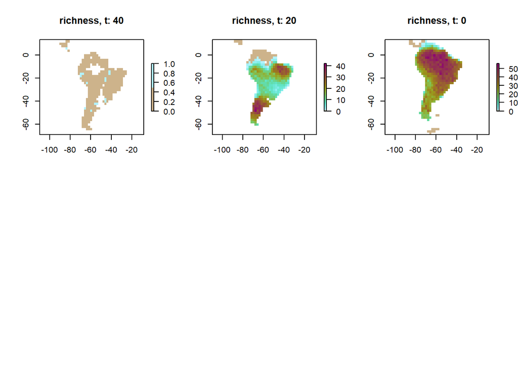

```r
timesteps <- c(40, 20, 0)

oldpar <- par(no.readonly = TRUE) # save original parameters

par(mfrow = c(2, 3))


for (i in timesteps) {
  landscape_i <- readRDS(
    file.path(
      data_path,
      paste0(
        "output/sim0/config_southamerica/landscapes/landscape_t_",
        i, ".rds"
      )
    )
  )
  species_i <- readRDS(
    file.path(
      data_path,
      paste0(
        "output/sim0/config_southamerica/species/species_t_",
        i, ".rds"
      )
    )
  )

  plot_richness(species_i, landscape_i)
}


par(oldpar) # reset to original parameters
```

# ❇️Activity: Modify the simulation

Let’s change some of the parameters and **compare the species richness** between different configurations.

**⚠️Caution⚠️**

Some parameters will make the model run for a very long time. If your model has not finished after 5-10 minutes (max!), it’s time to stop.

## 🪄Modify abundance

```r
# Make a copy of the original config-file
config1 <- config_raw
```

The original function:

```r
config1$gen3sis$ecology$apply_ecology
```

```
function (abundance, traits, landscape, config)
{
    abundance_scale = 10
    abundance_threshold = 1
    survive <- abundance >= abundance_threshold
    abundance[!survive] <- 0
    abundance <- ((1 - abs(traits[, "temp"] - landscape[, "temp"])) *
        abundance_scale) * as.numeric(survive)
    abundance[abundance < abundance_threshold] <- 0
    k <- ((landscape[, "area"] * (landscape[, "arid"] + 0.1) *
        (landscape[, "temp"] + 0.1)) * abundance_scale^2)
    total_ab <- sum(abundance)
    subtract <- total_ab - k
    if (subtract > 0) {
        while (total_ab > k) {
            alive <- abundance > 0
            loose <- sample(1:length(abundance[alive]), 1)
            abundance[alive][loose] <- abundance[alive][loose] -
                1
            total_ab <- sum(abundance)
        }
        abundance[!alive] <- 0
    }
    return(abundance)
}
<environment: 0x000002630eb55998>
```

Now you would usually open the config.R file and replace the function in the code with your adjustments. If you want to play around with the numbers, you can do it just like this:

```r
file.edit(here(data_path, "config" , "config_sim1.R"))
```

**New apply_ecology function:**

```r
# Let's modify it ===========================

config1$gen3sis$ecology$apply_ecology <- function(abundance, traits, landscape, config) {
  ## Change here:

  abundance_scale <- 5 # change here
  abundance_threshold <- 1 # and/or change here


  # abundance threshold
  survive <- abundance >= abundance_threshold
  abundance[!survive] <- 0
  abundance <- ((1 - abs(traits[, "temp"] - landscape[, "temp"])) * abundance_scale) * as.numeric(survive)


  # abundance threshold
  abundance[abundance < abundance_threshold] <- 0
  k <- ((landscape[, "area"] * (landscape[, "arid"] + 0.1) * (landscape[, "temp"] + 0.1)) * abundance_scale^2)
  total_ab <- sum(abundance)
  subtract <- total_ab - k

  if (subtract > 0) {
    # print(paste("should:", k, "is:", total_ab, "DIFF:", round(subtract,0) ))
    while (total_ab > k) {
      alive <- abundance > 0
      loose <- sample(1:length(abundance[alive]), 1)
      abundance[alive][loose] <- abundance[alive][loose] - 1
      total_ab <- sum(abundance)
    }
    # set negative abundances to zero
    abundance[!alive] <- 0
  }

  return(abundance)
}
```

```
[1] "config found: C:/Users/wolke/OneDrive - CZU v Praze/Dokumenty/Documents/GitHub/Teaching/Spatial-Ecology-and-Macroecology/Practical_classes/Week8_evolution_of_biodiversity/2_EcoEvoSimulations/SouthAmerica/config/config_sim1.R"
[1] "landscape found: C:/Users/wolke/OneDrive - CZU v Praze/Dokumenty/Documents/GitHub/Teaching/Spatial-Ecology-and-Macroecology/Practical_classes/Week8_evolution_of_biodiversity/2_EcoEvoSimulations/SouthAmerica/landscape"
[1] "output directory is: C:/Users/wolke/OneDrive - CZU v Praze/Dokumenty/Documents/GitHub/Teaching/Spatial-Ecology-and-Macroecology/Practical_classes/Week8_evolution_of_biodiversity/2_EcoEvoSimulations/SouthAmerica/output/sim1/config_sim1"
```

```
step = 40 , species alive = 10 , species total = 10
```

```
step = 39 , species alive = 10 , species total = 10
```

```
step = 38 , species alive = 10 , species total = 10
```

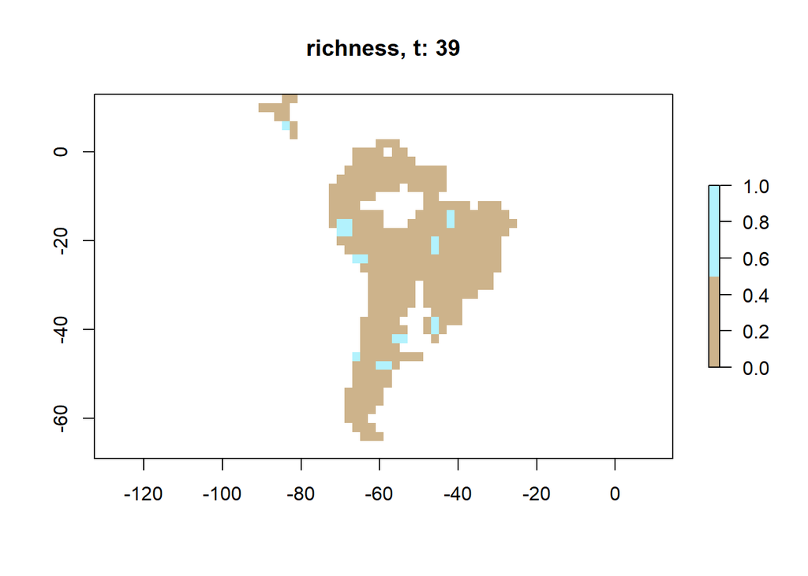

```
step = 37 , species alive = 13 , species total = 13
```

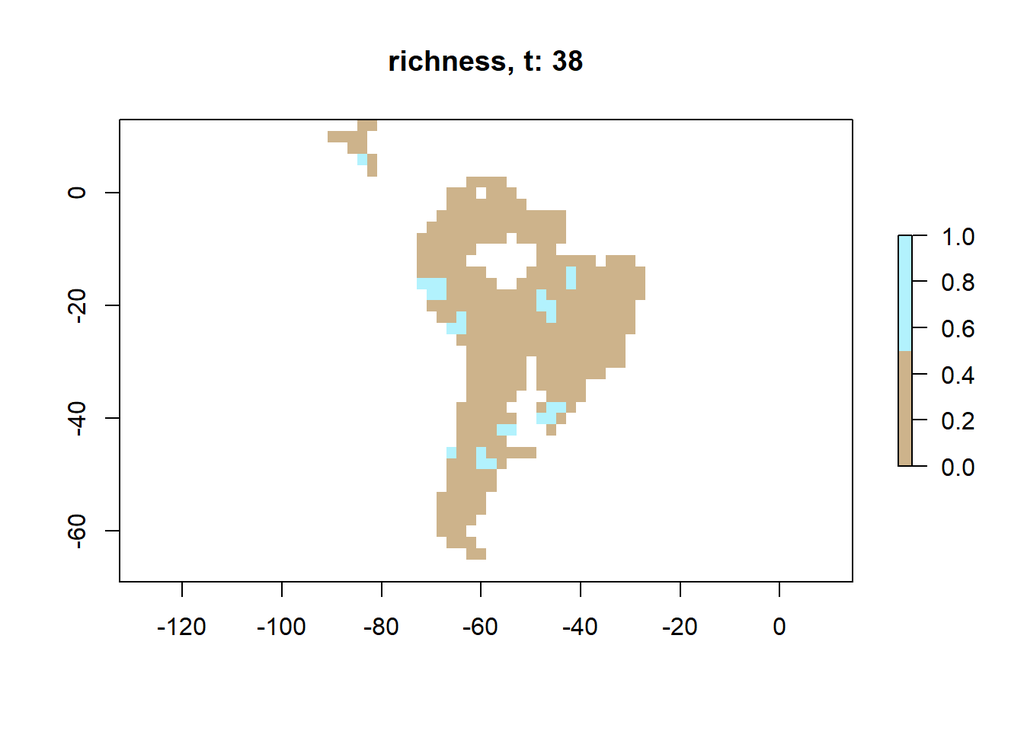

```
step = 36 , species alive = 15 , species total = 16
```

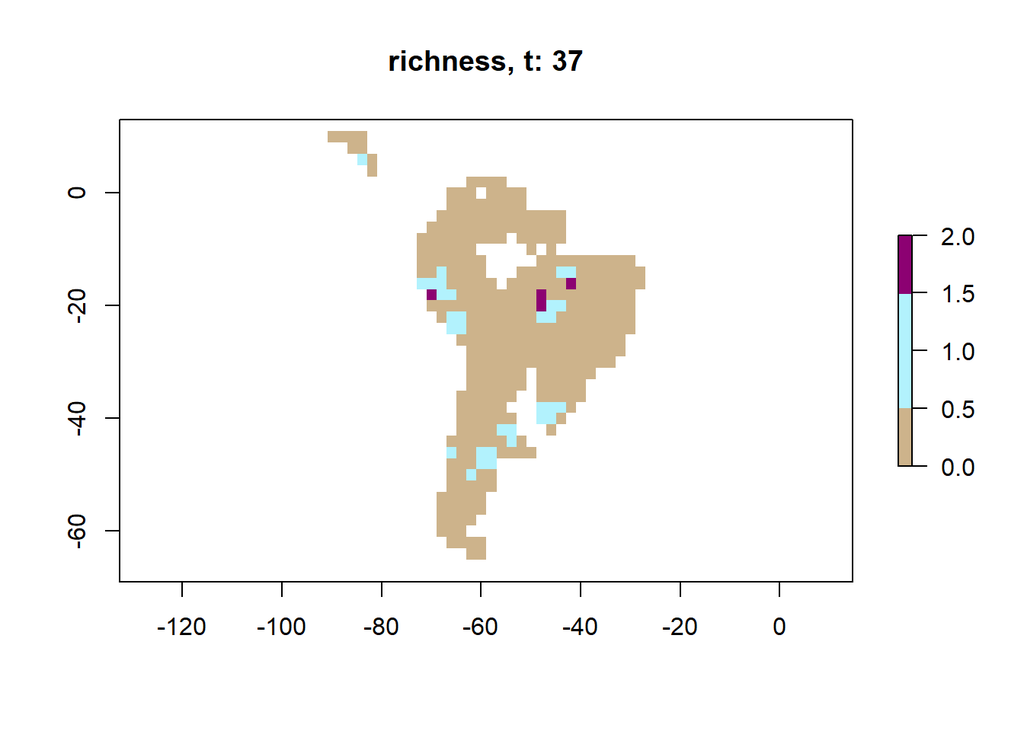

```
step = 35 , species alive = 21 , species total = 22
```

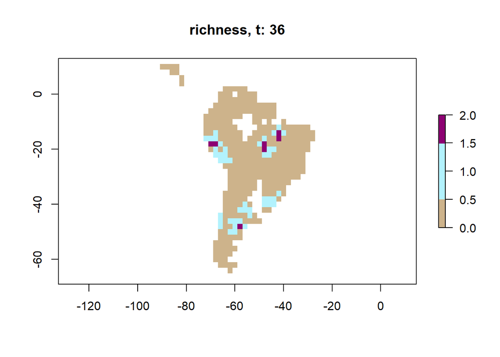

```
step = 34 , species alive = 34 , species total = 35
```

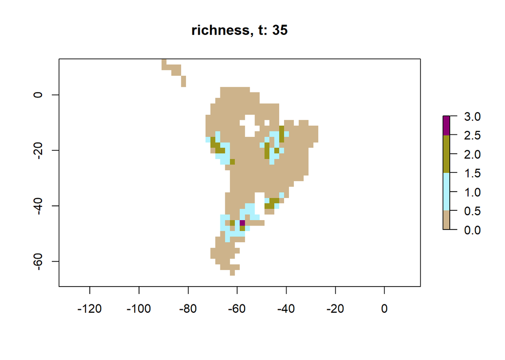

```
step = 33 , species alive = 43 , species total = 44
```

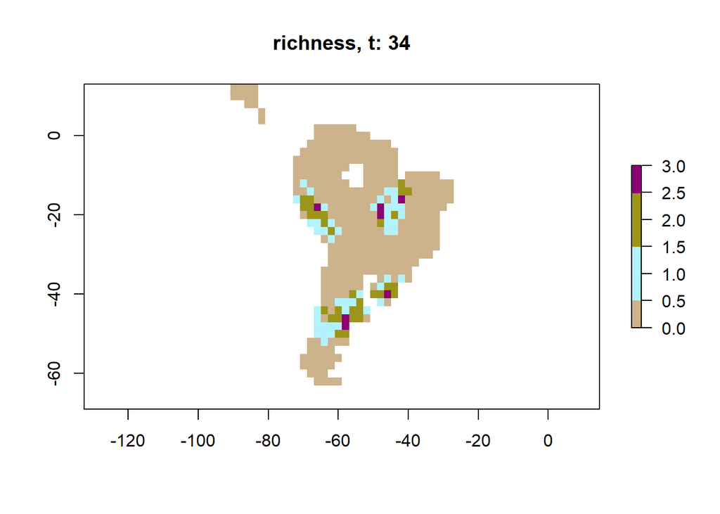

```
step = 32 , species alive = 59 , species total = 60
```

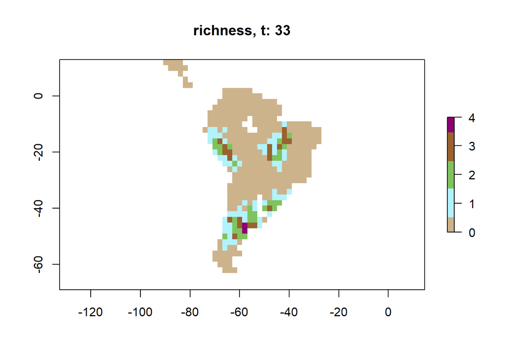

```
step = 31 , species alive = 81 , species total = 82
```

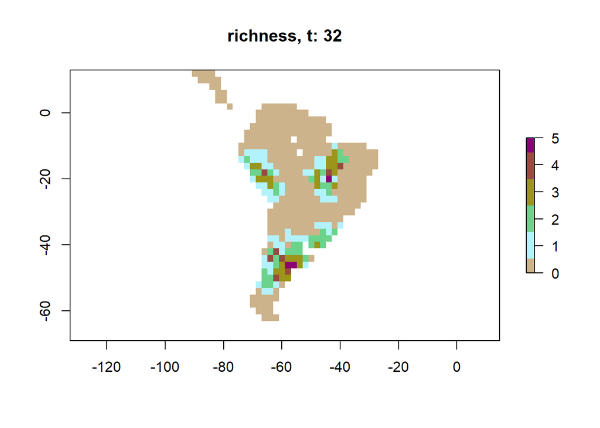

```
step = 30 , species alive = 114 , species total = 117
```

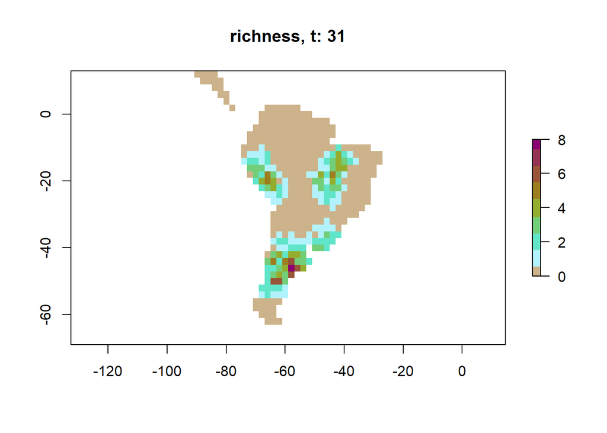

```
step = 29 , species alive = 159 , species total = 169
```

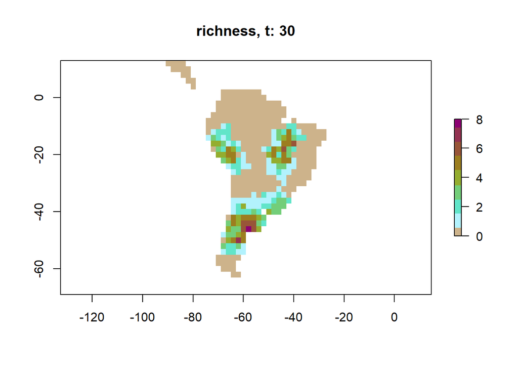

```
step = 28 , species alive = 209 , species total = 226
```

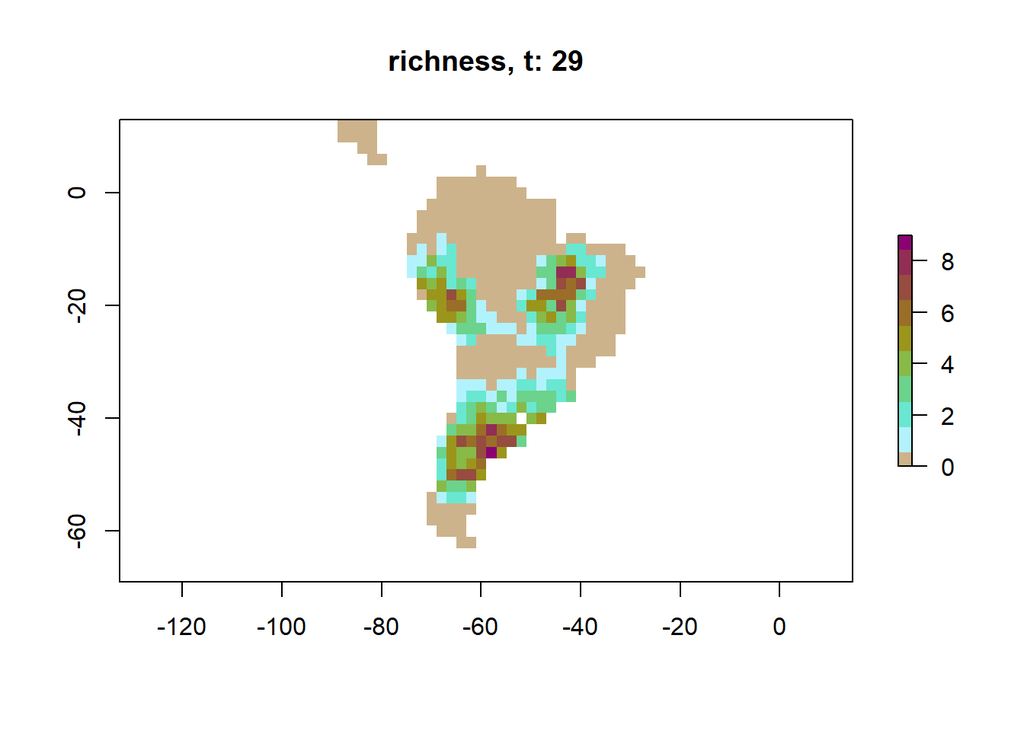

```
step = 27 , species alive = 279 , species total = 315
```

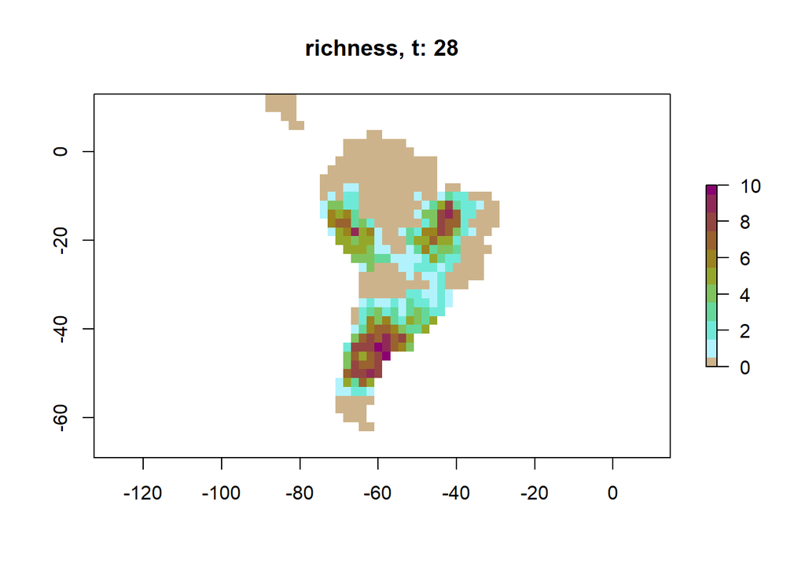

```
step = 26 , species alive = 360 , species total = 416
```

[28 more figures not shown]

```
Simulation finished. All OK
Simulation runtime: 0.05561364 hours
```

```r
# Run the simulation with the new configuration ======================
tictoc::tic("sim1")
sim1 <- run_simulation(
  config = file.path(data_path, "config/config_sim1.R"),
  landscape = file.path(data_path, "landscape"),
  output_directory = file.path(data_path, "output/sim1"),
  call_observer = "all",
  verbose = 1
)
```

```r
tictoc::toc()
```

```
sim1: 200.41 sec elapsed
```

```r
# Check the difference to the original simulation ================
plot_summary(sim0) # original
```

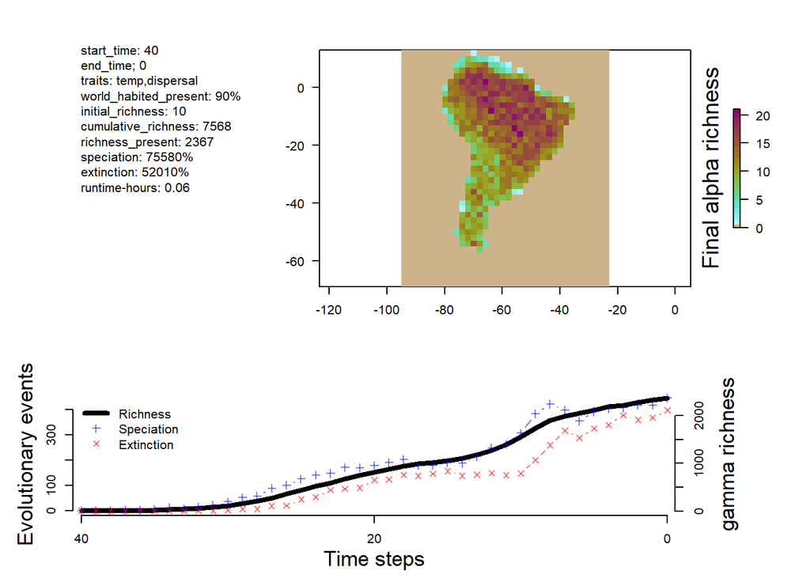

```r
plot_summary(sim1) # changed
```

## 🪄Changing the ancestor

```r
config_2 <- config_raw
```

```r
# The original function:
config_2$gen3sis$initialization$create_ancestor_species
```

```
function (landscape, config)
{
    range <- c(-95, -24, -68, 13)
    co <- landscape$coordinates
    selection <- co[, "x"] >= range[1] & co[, "x"] <= range[2] &
        co[, "y"] >= range[3] & co[, "y"] <= range[4]
    new_species <- list()
    for (i in 1:10) {
        initial_cells <- rownames(co)[selection]
        initial_cells <- sample(initial_cells, 1)
        new_species[[i]] <- create_species(initial_cells, config)
        new_species[[i]]$traits[, "temp"] <- landscape$environment[initial_cells,
            "temp"]
        new_species[[i]]$traits[, "dispersal"] <- 1
    }
    return(new_species)
}
<environment: 0x000002630eb55998>
```

**New create_ancestor_species function:**

```r
# Let's modify it. E.g., only 1 ancestor species (instead of 10)


config_2$gen3sis$initialization$create_ancestor_species <- function(landscape, config) {
  range <- c(-95, -24, -68, 13)
  co <- landscape$coordinates
  selection <- co[, "x"] >= range[1] &
    co[, "x"] <= range[2] &
    co[, "y"] >= range[3] &
    co[, "y"] <= range[4]

  new_species <- list()


  ## Change number of ancestral species in the top of the loop: e.g.: for (i in 1:20) for 20 ancestral species
  for (i in 1:1) {
    initial_cells <- rownames(co)[selection]
    initial_cells <- sample(initial_cells, 1)
    new_species[[i]] <- create_species(initial_cells, config)
    # set local adaptation to max optimal temp equals local temp
    new_species[[i]]$traits[, "temp"] <- landscape$environment[initial_cells, "temp"]
    new_species[[i]]$traits[, "dispersal"] <- 1
    # plot_species_presence(landscape, species=new_species[[i]])
  }

  return(new_species)
}
```

```
[1] "config found: C:/Users/wolke/OneDrive - CZU v Praze/Dokumenty/Documents/GitHub/Teaching/Spatial-Ecology-and-Macroecology/Practical_classes/Week8_evolution_of_biodiversity/2_EcoEvoSimulations/SouthAmerica/config/config_sim2.R"
[1] "landscape found: C:/Users/wolke/OneDrive - CZU v Praze/Dokumenty/Documents/GitHub/Teaching/Spatial-Ecology-and-Macroecology/Practical_classes/Week8_evolution_of_biodiversity/2_EcoEvoSimulations/SouthAmerica/landscape"
[1] "output directory is: C:/Users/wolke/OneDrive - CZU v Praze/Dokumenty/Documents/GitHub/Teaching/Spatial-Ecology-and-Macroecology/Practical_classes/Week8_evolution_of_biodiversity/2_EcoEvoSimulations/SouthAmerica/output/sim2/config_sim2"
```

```
step = 40 , species alive = 1 , species total = 1
```

```
step = 39 , species alive = 1 , species total = 1
step = 38 , species alive = 1 , species total = 1
step = 37 , species alive = 2 , species total = 2
step = 36 , species alive = 2 , species total = 2
step = 35 , species alive = 2 , species total = 2
step = 34 , species alive = 2 , species total = 2
step = 33 , species alive = 2 , species total = 2
step = 32 , species alive = 2 , species total = 2
step = 31 , species alive = 2 , species total = 2
step = 30 , species alive = 4 , species total = 4
step = 29 , species alive = 5 , species total = 5
step = 28 , species alive = 7 , species total = 7
step = 27 , species alive = 10 , species total = 10
step = 26 , species alive = 10 , species total = 10
step = 25 , species alive = 17 , species total = 17
step = 24 , species alive = 24 , species total = 24
step = 23 , species alive = 33 , species total = 33
step = 22 , species alive = 42 , species total = 42
step = 21 , species alive = 59 , species total = 61
step = 20 , species alive = 60 , species total = 75
```

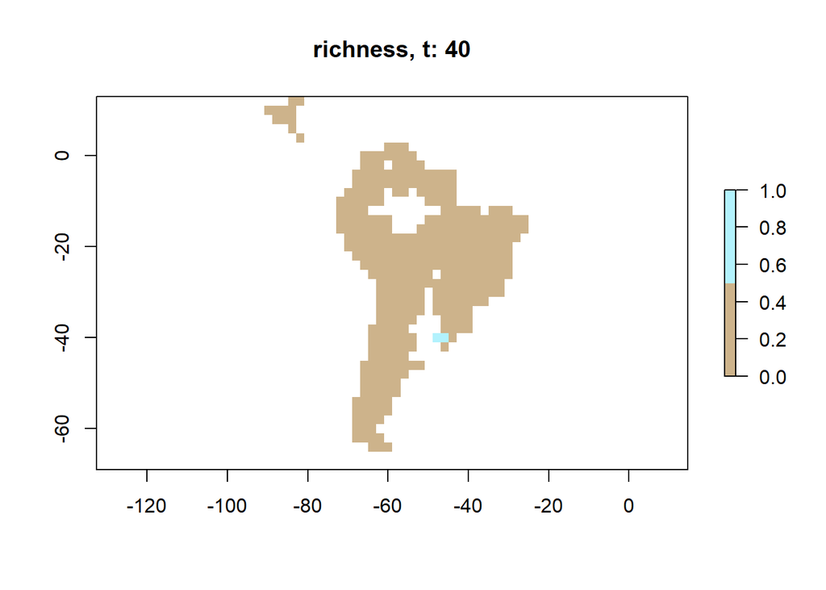

```
step = 19 , species alive = 75 , species total = 102
step = 18 , species alive = 100 , species total = 131
step = 17 , species alive = 109 , species total = 158
step = 16 , species alive = 125 , species total = 186
step = 15 , species alive = 137 , species total = 210
step = 14 , species alive = 162 , species total = 248
step = 13 , species alive = 179 , species total = 279
step = 12 , species alive = 223 , species total = 335
step = 11 , species alive = 289 , species total = 410
step = 10 , species alive = 356 , species total = 494
step = 9 , species alive = 470 , species total = 631
step = 8 , species alive = 627 , species total = 813
step = 7 , species alive = 803 , species total = 1035
step = 6 , species alive = 1038 , species total = 1329
step = 5 , species alive = 1220 , species total = 1630
step = 4 , species alive = 1437 , species total = 2001
step = 3 , species alive = 1606 , species total = 2419
step = 2 , species alive = 1761 , species total = 2833
step = 1 , species alive = 1937 , species total = 3280
step = 0 , species alive = 2005 , species total = 3682
```

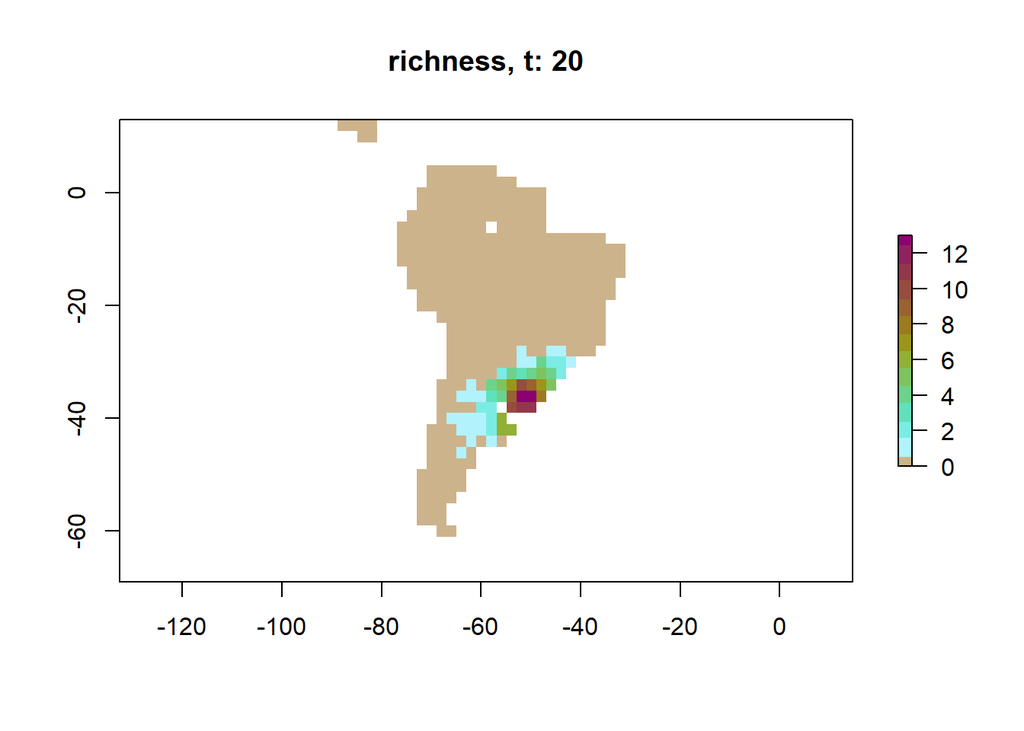

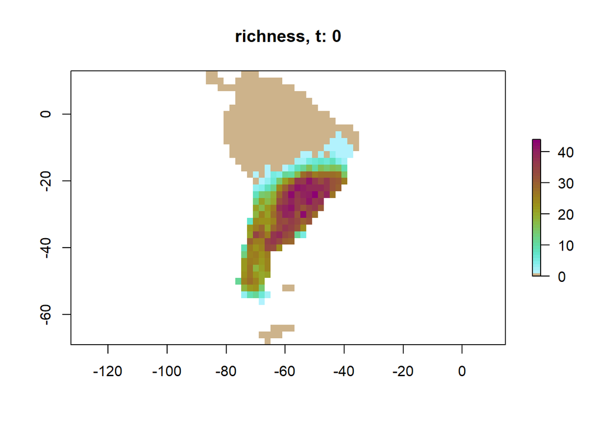

```
Simulation finished. All OK
Simulation runtime: 0.01491307 hours
```

```r
tictoc::tic("sim2")
# Run the simulation with the new configuration
sim2 <- run_simulation(
  config = file.path(data_path, "config/config_sim2.R"),
  landscape = file.path(data_path, "landscape"),
  output_directory = file.path(data_path, "output/sim2"),
  call_observer = 1,
  verbose = 1
)
```

```r
tictoc::toc()
```

```
sim2: 53.81 sec elapsed
```

```r
# Get the summary
plot_summary(sim0)
```

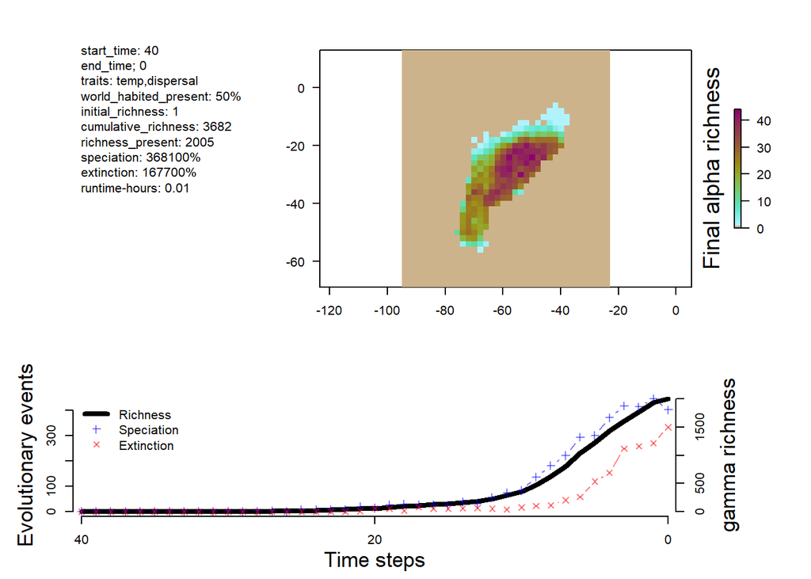

```r
plot_summary(sim2)
```

## 🪄Decreased Dispersal distance

**The Weibull distribution - test it:**

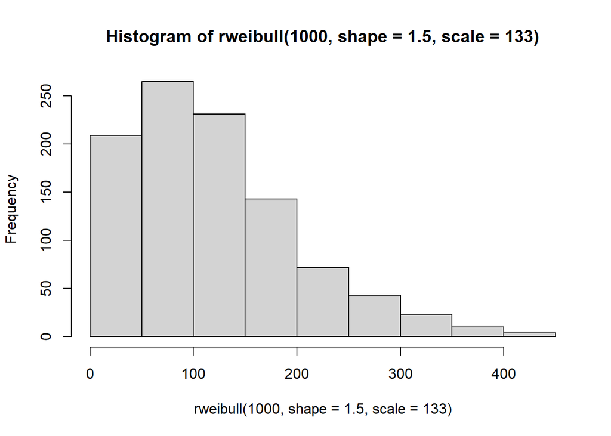

```r
# scale parameter = this is where the distribution is centered around
# shape parameter = indicates how sharp the curve is going to be

hist(rweibull(1000, shape = 1.5, scale = 133)) # Original distribution of dispersal values
```

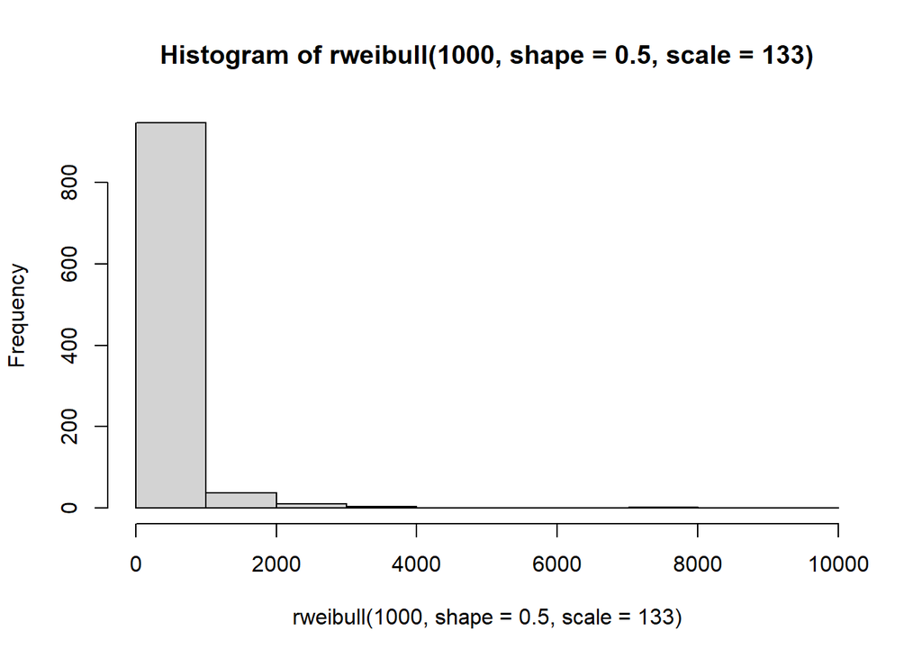

```r
# Play around with some values. What do you observe?

## Examples:
# changed shape parameter:
hist(rweibull(1000, shape = 0.5, scale = 133))
```

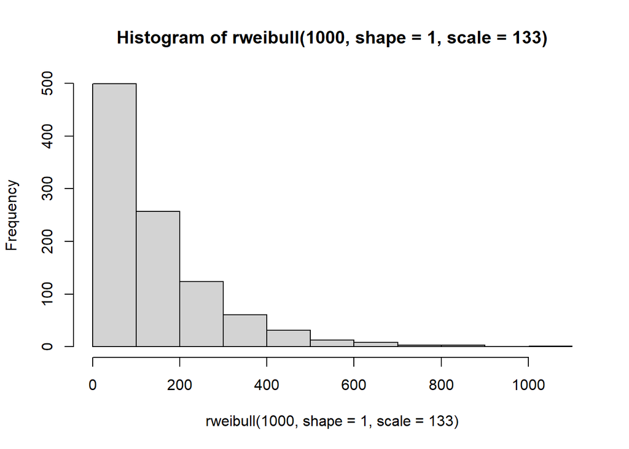

```r
hist(rweibull(1000, shape = 1, scale = 133))
```

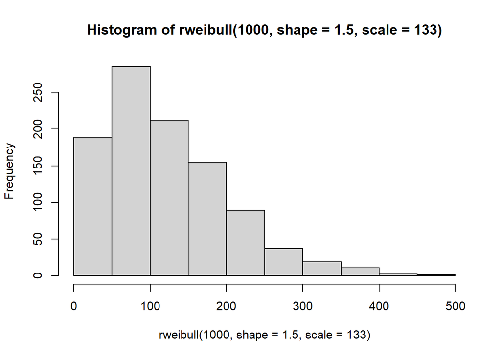

```r
hist(rweibull(1000, shape = 1.5, scale = 133))
```

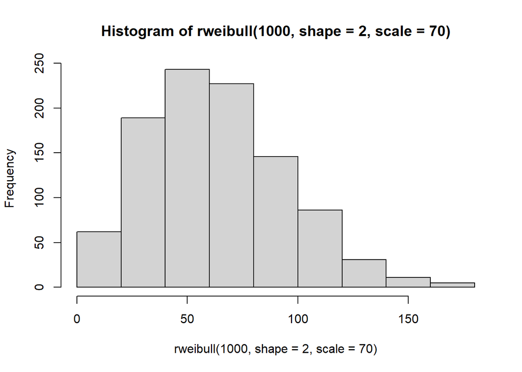

```r
# changed scale paramer:
hist(rweibull(1000, shape = 2, scale = 70))
```

**Task**

Change the arguments of the Weibull distribution to achieve a lower dispersal distance for the model. What happens?

*Caution: Increasing the dispersal distance increases computing time a lot!*

*scale = 200 took me 25 minutes to simulate.*

*For time reasons, we should stick to decreasing it during the practical course.*

```r
# create a copy of the config file that we can change
config3 <- config_raw
```

```r
# Original function =========
config3$gen3sis$dispersal$get_dispersal_values
```

```
function (n, species, landscape, config)
{
    values <- rweibull(n, shape = 1.5, scale = 133)
    return(values)
}
<environment: 0x000002630eb55998>
```

**New get_dispersal_values function:**

```r
# change the function =========
config3$gen3sis$dispersal$get_dispersal_values <- function(n, species, landscape, config) {
  values <- rweibull(n, shape = 2, scale = 100)

  return(values)
}
```

```
[1] "config found: C:/Users/wolke/OneDrive - CZU v Praze/Dokumenty/Documents/GitHub/Teaching/Spatial-Ecology-and-Macroecology/Practical_classes/Week8_evolution_of_biodiversity/2_EcoEvoSimulations/SouthAmerica/config/config_sim3.R"
[1] "landscape found: C:/Users/wolke/OneDrive - CZU v Praze/Dokumenty/Documents/GitHub/Teaching/Spatial-Ecology-and-Macroecology/Practical_classes/Week8_evolution_of_biodiversity/2_EcoEvoSimulations/SouthAmerica/landscape"
[1] "output directory is: C:/Users/wolke/OneDrive - CZU v Praze/Dokumenty/Documents/GitHub/Teaching/Spatial-Ecology-and-Macroecology/Practical_classes/Week8_evolution_of_biodiversity/2_EcoEvoSimulations/SouthAmerica/output/sim3/config_sim3"
```

```
step = 40 , species alive = 10 , species total = 10
```

```
step = 39 , species alive = 10 , species total = 10
step = 38 , species alive = 10 , species total = 10
step = 37 , species alive = 10 , species total = 10
step = 36 , species alive = 10 , species total = 11
step = 35 , species alive = 10 , species total = 11
step = 34 , species alive = 10 , species total = 11
step = 33 , species alive = 10 , species total = 11
step = 32 , species alive = 11 , species total = 12
step = 31 , species alive = 11 , species total = 12
step = 30 , species alive = 13 , species total = 14
step = 29 , species alive = 13 , species total = 15
step = 28 , species alive = 16 , species total = 18
step = 27 , species alive = 16 , species total = 18
step = 26 , species alive = 16 , species total = 18
step = 25 , species alive = 16 , species total = 19
step = 24 , species alive = 17 , species total = 20
step = 23 , species alive = 18 , species total = 21
step = 22 , species alive = 19 , species total = 22
step = 21 , species alive = 19 , species total = 22
step = 20 , species alive = 20 , species total = 24
```

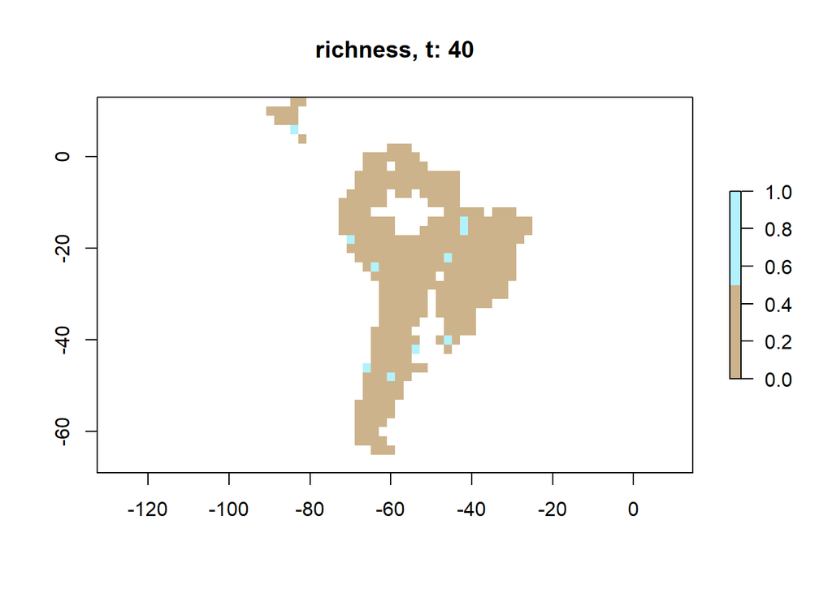

```
step = 19 , species alive = 20 , species total = 25
step = 18 , species alive = 20 , species total = 28
step = 17 , species alive = 22 , species total = 30
step = 16 , species alive = 24 , species total = 32
step = 15 , species alive = 28 , species total = 36
step = 14 , species alive = 31 , species total = 39
step = 13 , species alive = 28 , species total = 39
step = 12 , species alive = 28 , species total = 40
step = 11 , species alive = 28 , species total = 42
step = 10 , species alive = 25 , species total = 43
step = 9 , species alive = 27 , species total = 45
step = 8 , species alive = 29 , species total = 48
step = 7 , species alive = 32 , species total = 51
step = 6 , species alive = 35 , species total = 54
step = 5 , species alive = 37 , species total = 56
step = 4 , species alive = 40 , species total = 61
step = 3 , species alive = 46 , species total = 67
step = 2 , species alive = 52 , species total = 73
step = 1 , species alive = 57 , species total = 78
step = 0 , species alive = 63 , species total = 84
```

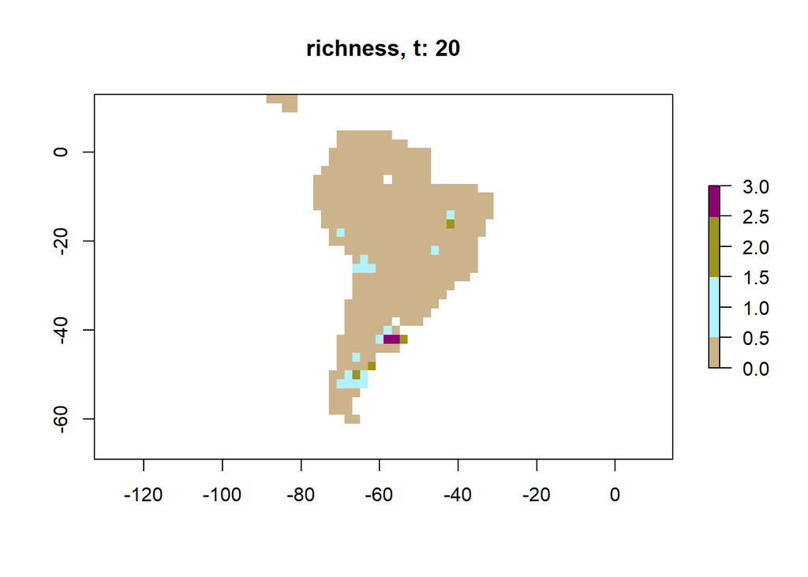

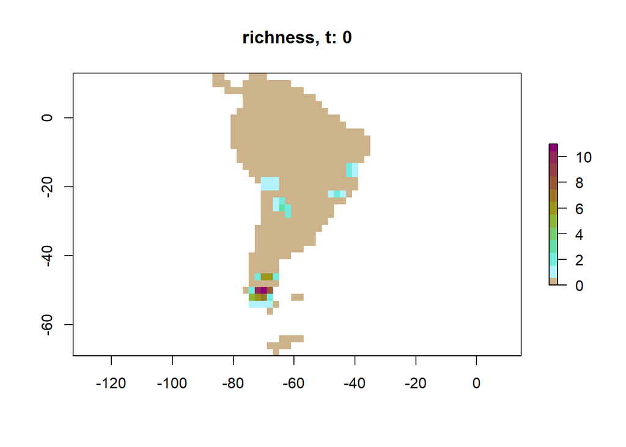

```
Simulation finished. All OK
Simulation runtime: 0.002533406 hours
```

```r
tictoc::tic("sim3")
# Run the simulation with the new configuration =========
sim3 <- run_simulation(
  config = file.path(data_path, "config/config_sim3.R"),
  landscape = file.path(data_path, "landscape"),
  output_directory = file.path(data_path, "output/sim3"),
  call_observer = 1,
  verbose = 1
)
```

```r
tictoc::toc()
```

```
sim3: 9.18 sec elapsed
```

```r
## What is different?
plot_summary(sim0)
```

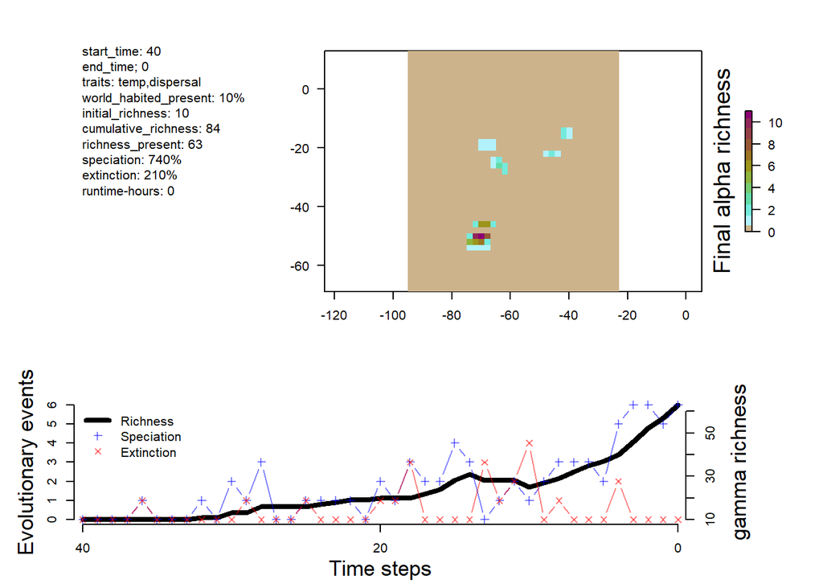

```r
plot_summary(sim3)
```